# CMSC320 Uber Trends NYC Final Project

Rohan Kumar, Ryan Lam, Emmanuel Benyam

##### Concern of our study:

Joining Uber’s extensive club of drivers seems as simple as get a car, get the app and get paid. Although this industry and life changing application creates a quick and convenient opportunity to generate revenue, the process itself isn’t without it’s faults. People that have joined Uber have voiced their experiences and highlight the problem of extensive wait time between customers. Others may have issues of planning out adequate times for driving for Uber due to other job or life constraints.

##### How we will conduct research:

For our study, we’ve decided to focus our attention on one extremely popular area for Uber in the United States, New York City. We set out to study the trends of Uber pickups that occurred within New York City from January 2015 to June 2015 under various conditions such as location, time of day, day of the week, and various atmospheric conditions. By doing so, we hope to understand an average 24 hour day with Uber and conclude any trends that may assist drivers in being more successful and efficient with their routes. The purpose of this research is to demonstrate to those who want to join Uber as drivers, or current Uber drivers, what conditions may affect their daily lives and understand if working for Uber is worth the investment, time and in general if it corresponds with their schedules.

### 1.1 Getting the Data

```r
library(tidyverse) #Data Manipulation
library(dplyr) #Data Manipulation
library(lubridate) #Date/time parsing
library(scales) #Visualiztion aid
library(ggplot2) #Visualization
library(rvest) #Webscraping
library(magrittr) #Data manipulation
library(scales) # Visualization aid

uber_data <- read.csv("/Users/ryanlam/Desktop/CMSC320/FINAL/uber_nyc_enriched.csv")
uber_data <- set_colnames(uber_data, c("Date", "Borough", "No. of Pickups", "Wind Speed", "Visibility", "Temperature", "Dew Point", "Sea Level Pressure", "1Hour Liquid Precipitation", "6Hour Liquid Precipitation", "24Hour Liquid Precipitation", "Snow Depth", "Holiday")) %>% as.data.frame()

uber_data$Temperature <- as.integer(uber_data$Temperature)
uber_data <- uber_data %>% mutate_if(is.factor, as.character)

uber_data$Time <- format(as.POSIXct(uber_data$Date,tz=""), format = "%H:%M:%S")
uber_data$FullDate <- format(as.POSIXct(uber_data$Date,tz=""), format = "%Y-%m-%d")

uber_data$FullDate <- as.POSIXct(uber_data$FullDate)
uber_data$Time_Dbl <- as.numeric(hms(uber_data$Time))/3600
uber_data$Num_time <- as.POSIXct(uber_data$Date, format="%Y-%m-%d %H:%M")

head(uber_data)
```

```
##                  Date       Borough No. of Pickups Wind Speed Visibility
## 1 2015-01-01 01:00:00         Bronx            152          5         10
## 2 2015-01-01 01:00:00      Brooklyn           1519          5         10
## 3 2015-01-01 01:00:00           EWR              0          5         10
## 4 2015-01-01 01:00:00     Manhattan           5258          5         10
## 5 2015-01-01 01:00:00        Queens            405          5         10
## 6 2015-01-01 01:00:00 Staten Island              6          5         10
##   Temperature Dew Point Sea Level Pressure 1Hour Liquid Precipitation
## 1          30         7             1023.5                          0
## 2          30         7             1023.5                          0
## 3          30         7             1023.5                          0
## 4          30         7             1023.5                          0
## 5          30         7             1023.5                          0
## 6          30         7             1023.5                          0
##   6Hour Liquid Precipitation 24Hour Liquid Precipitation Snow Depth Holiday
## 1                          0                           0          0       Y
## 2                          0                           0          0       Y
## 3                          0                           0          0       Y
## 4                          0                           0          0       Y
## 5                          0                           0          0       Y
## 6                          0                           0          0       Y
##       Time   FullDate Time_Dbl            Num_time
## 1 01:00:00 2015-01-01        1 2015-01-01 01:00:00
## 2 01:00:00 2015-01-01        1 2015-01-01 01:00:00
## 3 01:00:00 2015-01-01        1 2015-01-01 01:00:00
## 4 01:00:00 2015-01-01        1 2015-01-01 01:00:00
## 5 01:00:00 2015-01-01        1 2015-01-01 01:00:00
## 6 01:00:00 2015-01-01        1 2015-01-01 01:00:00
```

We chose to use this CSV file because it combined uber data with weather/climate data which we thought would be interesting to find relationships between. In order to use this data, we needed to parse some columns into usable data types. The date is one of the most important columns that we needed to convert into a POSTIXct class from a chr class. This allowed us to plot our data and this conversion step was necessary to analyze this data.

We noticed that this dataset had insignificant minute and second values since they were all 0. The only value that changed for time was the hour which allowed us to make a new column called Time_dbl which converted the time to a double that ranged values between 0-23 (0 is midnight and 23 is 11:00PM).

We also needed to convert the date from chr to the POSTIXct class which was done in the FullDate column. We also converted to Num_time just in case we needed the full date and time as a POSIXct class in order to aggregate data.

### 1.2 Snowfall Versus Uber Pickups

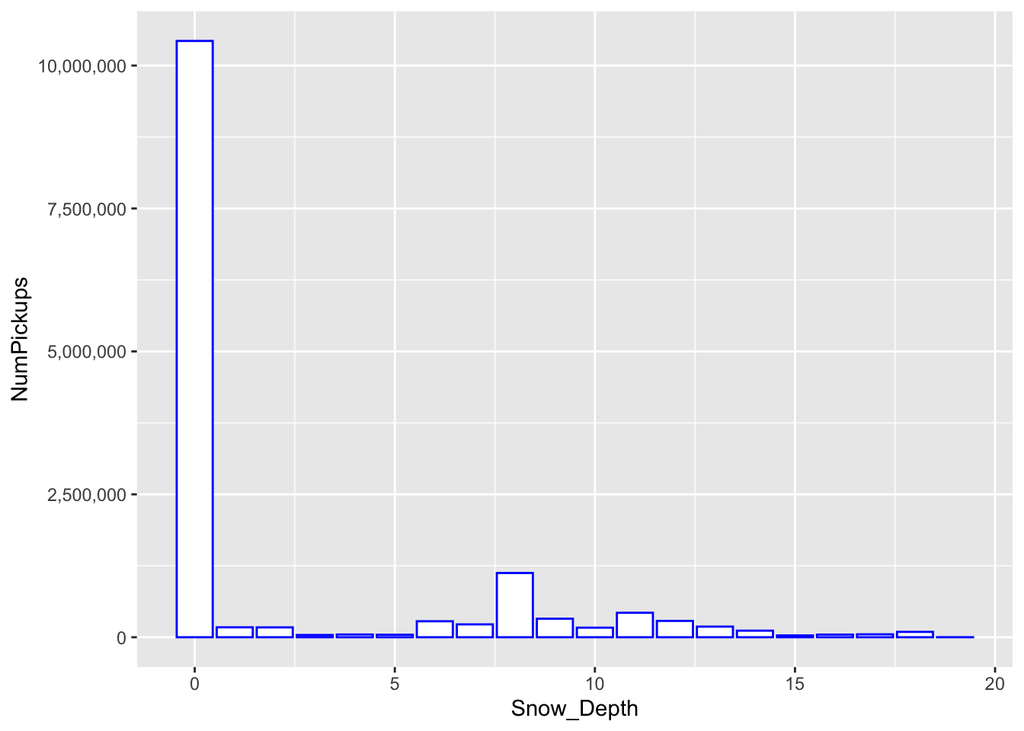

```r
uber_data %>%
  group_by(Snow_Depth = floor(`Snow Depth`)) %>%
  summarize(NumPickups=sum(`No. of Pickups`)) %>%
  ggplot(mapping=aes(x=Snow_Depth, y=NumPickups)) +
  geom_bar(stat="identity", color="blue", fill="white") +
  scale_y_continuous(labels = scales::comma)
```

In order to get this graph, we will need a pipeline. We first read in our uber_data dataframe and immediately use the group_by method. The group_by method is useful for grouping columns within a dataframe based on certain conditions. In this case, we grouped by the snow depth and took the floor of the values in order to get more organized data. This splits up the data by snow depth.

We then pipe the results into a summarize method which summarizes the number of pickups based on our group_by that we used one line above. The way we used this method was to sum up pick ups based on the different snow depth values. When printed, we will see the x value as snow fall and y values of the sum of all pickups based on snowfall values.

The goal of this plot is to see if there is some sort of correlation between snow depth and number of pickups. From looking at the plot, there is no straight-forward pattern on how snow affects the number of pick ups.

### 1.3 Number of Pickups Versus Month

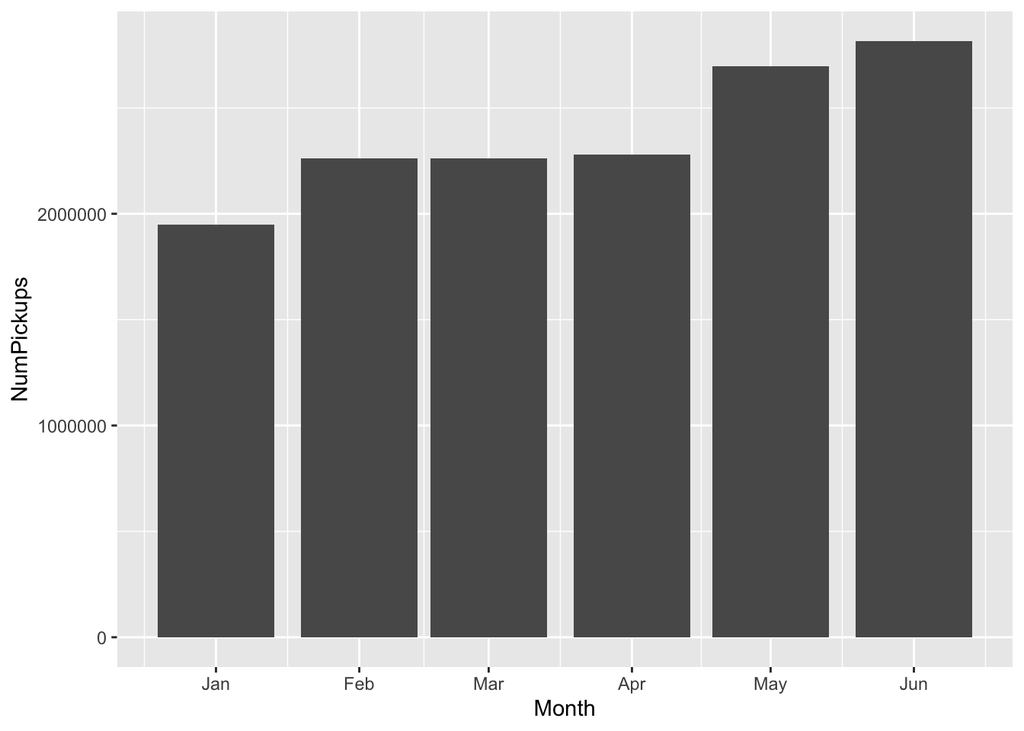

```r
#Visualizing different variations of data to understand the frequency of Ubers based on different factors
uber_data %>%
  group_by(Month=floor_date(FullDate, "month")) %>%
  summarize(NumPickups=sum(`No. of Pickups`)) %>%
  ggplot(mapping=aes(x = Month, y = NumPickups)) + geom_bar(stat = "identity")+ scale_y_continuous(labels = function(x) format(x, scientific = FALSE))
```

For this graph, we decided to look at the number of pickups from Uber drivers that occur each month. We figured this data would give us an understanding of any relationship that might exist between the number of pickups from Uber and time of the year. Our initial hypothesis was that there would be a higher number of Uber pickups that occurred in the months of January to March due to increasing weather that may encourage people to use Uber. However, based on the diagram above, we noticed that there was a positive correlation between the number of pickups and time of the year with a peak in June. We concluded that this made sense due to the influx of tourists in NYC during the time of summer.

### 1.4 Number of Pickups Versus Borough

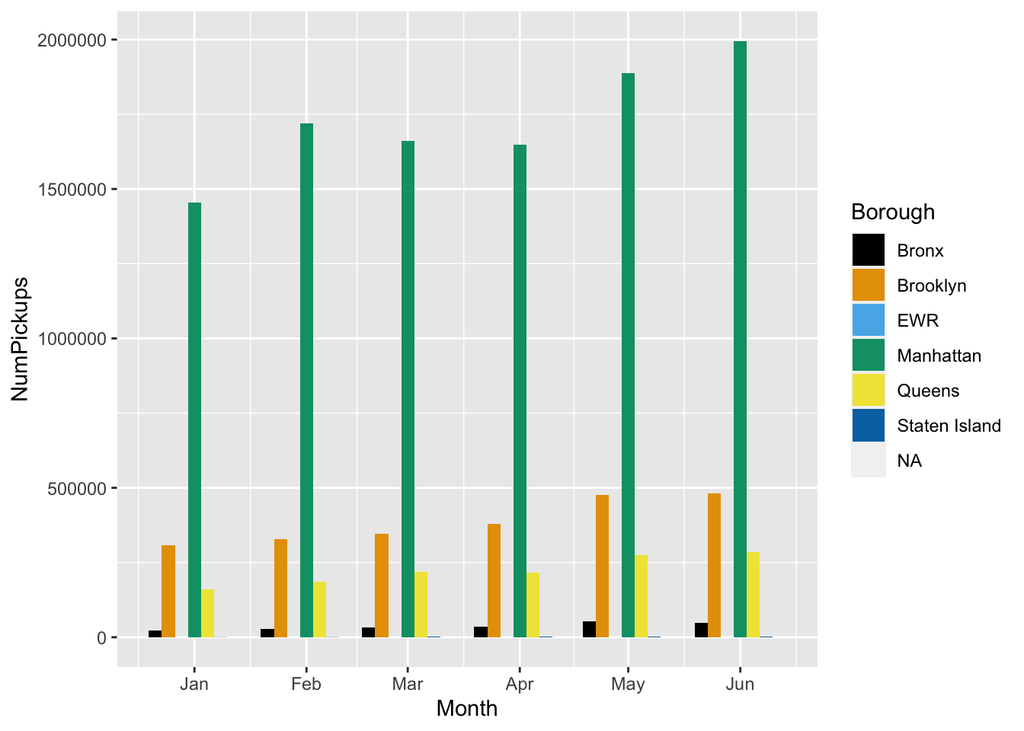

```r
cbp2 <- c("#000000", "#E69F00", "#56B4E9", "#009E73",
          "#F0E442", "#0072B2", "#D55E00", "#CC79A7")

uber_data %>%
  group_by(Month=floor_date(FullDate, "month"), Borough) %>%
  summarize(NumPickups=sum(`No. of Pickups`)) %>%
  ggplot(uber_data, mapping=aes(x = Month, y = NumPickups, fill = Borough)) + geom_bar(stat = "identity", position=position_dodge()) + scale_y_continuous() + scale_fill_manual(values = cbp2)
```

We wanted to visually see if there was any correlation between location in the city and Uber activity to help potential and current Uber drivers plan out where they might want to be active. Before creating this plot, we hypothesized that Manhattan would have the most activity in Uber pickups due to its size and activity. Additionally, based on the data we extrapolated from the graph on the monthly number of pickups from Ubers, Manhattan in June would see the most activity amongst Uber drivers.

### 1.5 Number of Pickups based on Varying Temperatures Per Month

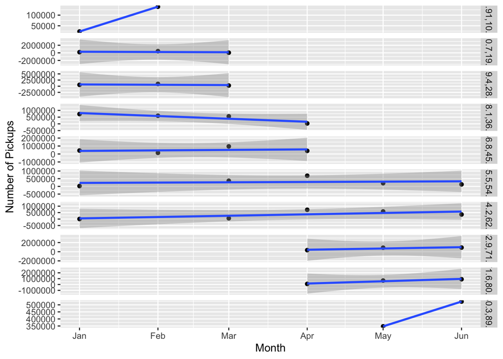

```r
uber_data <- uber_data %>%
    mutate(TempBreak=cut(Temperature, breaks=10))

uber_data %>%
  group_by(Month=floor_date(FullDate, "month"), TempBreak) %>%
  summarize(NumPickups=sum(`No. of Pickups`)) %>%
  ggplot(mapping=aes(x=Month, y=NumPickups)) + facet_grid(TempBreak~., scales = "free") + geom_point() + geom_smooth(method=lm) + scale_y_continuous(labels = function(x) format(x, scientific = FALSE)) + labs(y="Number of Pickups")
```

### 1.6 Number of Pickups based on Visibility

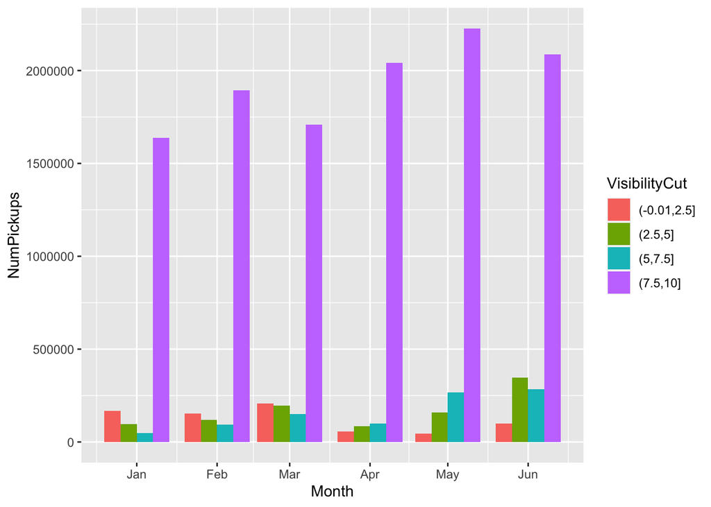

```r
uber_data %>%
  group_by(VisibilityCut=cut(Visibility, breaks = 4), Month=floor_date(FullDate, "month")) %>%
  summarize(NumPickups=sum(`No. of Pickups`)) %>%
  ggplot(mapping=aes(x = Month, y = NumPickups, fill = VisibilityCut)) + geom_bar(stat = "identity",position=position_dodge())+ scale_y_continuous(labels = function(x) format(x, scientific = FALSE))
```

This plot gets into the understanding of visibility and its relationship with the number of pickups. There are 4 different colors each representing different amounts of visibility. Furthermore, the data is also split into months of the year - with each month showing its own amounts of visibility.

To understand what this plot represents and provides us it is important to understand what “visibility” means in this context. Visibility is the amount of miles you can see ahead. This means that a higher visibility rating means it it less foggy and there is less precipitation.The plot reveals that there are more pickups when visibilities are higher as the “7.5,10” group has overwhelmingly larger numbers indicating that there are more business transactions going on on less foggy days.

### 2.1 Number of Pick ups Versus Holiday

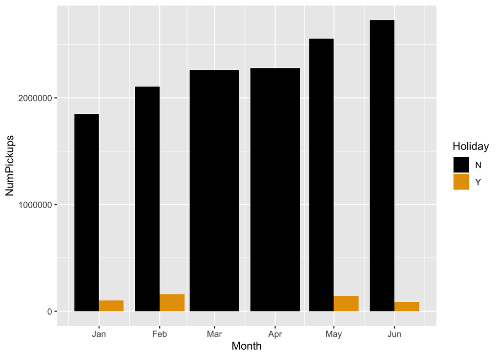

```r
uber_data %>%
  group_by(Month=floor_date(FullDate, "month"), Holiday) %>%
  summarize(NumPickups=sum(`No. of Pickups`)) %>%
  ggplot(uber_data, mapping=aes(x = Month, y = NumPickups, fill = Holiday)) + geom_bar(stat = "identity", position=position_dodge()) + scale_y_continuous(labels = function(x) format(x, scientific = FALSE)) + scale_fill_manual(values = cbp2)
```

This plot shows the number of uber pick ups based on holidays versus non-holidays. We expected there to be a large influx during the holidays but from looking at this graph, we can see that there is no clear corrleation between holidays versus non-holidays.

The way we plotted this was by using a pipeline. We first used the group_by method and split it by month. Our dataset has a yes/no column that indicates whether or not a day is a holiday or not. We used this parameter to group the dates that were a holiday versus those that were not. We then used the summarize method to obtain the number of pick ups for holidays and non holidays. Lastly, we used the ggplot function to plot the graph out.

Although this graph does not show any correlation, it is useful since it lets us know that holidays do not affect the number of pick ups positively or negatively. A better way to approach this if there was some sort of correlation is to standarize the data and see percent increases instead of raw sums.

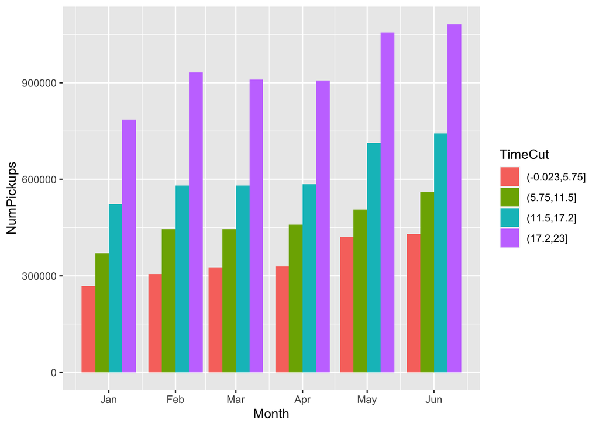

```r
uber_data %>%
  group_by(TimeCut=cut(Time_Dbl, breaks = 4), Month=floor_date(FullDate, "month")) %>%
  summarize(NumPickups=sum(`No. of Pickups`)) %>%
  ggplot(mapping=aes(x = Month, y = NumPickups, fill = TimeCut)) + geom_bar(stat = "identity",position=position_dodge())+ scale_y_continuous(labels = function(x) format(x, scientific = FALSE))
```

The plot above graphs the amount of pickups recorded for each month based on the time of day. There are four colors used when plotting each representing a different 6 hour time period of the day. For example, the last time period (in purple) spans the hours of 6,7,8,9,10 and 11 pm. We did not exactly predict a general trend among the different times of day. There was not much reason to speculate that one time of day would be more busier than the other, however, our graph reveals a different story. For each month graphed it appears that as the day progresses, more pickups occur. For each month, the first time period has the least amount of pickups, the second time period has more than that, and so on with the last time period having the most. Furthermore, as the months progress, we see the same trend and more of a gap between the last and first time period. We hypothesize that this is in part due to the sun being out longer as the months go by, yet we cannot fully be sure. Nonetheless, we clearly see that there is more business for Uber later in the day.

### 2.3 Number of Pickups Versus Weekdays

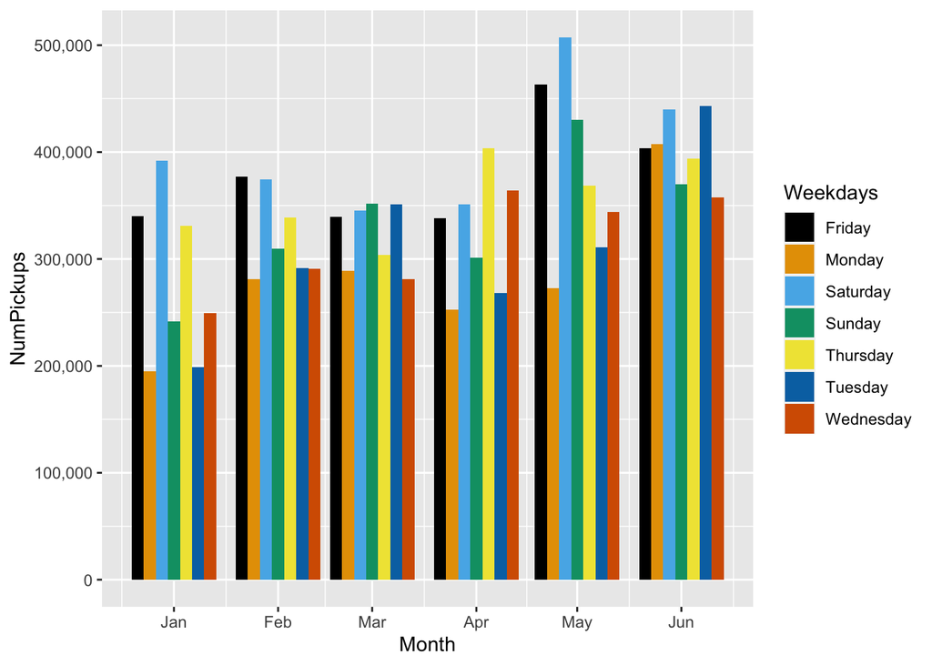

```r
uber_data$Weekdays <- as.Date(uber_data$Date)
uber_data$Weekdays <- weekdays(uber_data$Weekdays)

uber_data %>%
  group_by(Month=floor_date(FullDate, "month"), Weekdays) %>%
  summarize(NumPickups=sum(`No. of Pickups`)) %>%
  ggplot(uber_data, mapping=aes(x = Month, y = NumPickups, fill = Weekdays)) + geom_bar(stat = "identity", position=position_dodge()) + scale_y_continuous() + scale_fill_manual(values = cbp2) +   scale_y_continuous(labels = scales::comma)
```

### 2.4 Box and Whisker Plot, Number of Pickups Versus Weekday

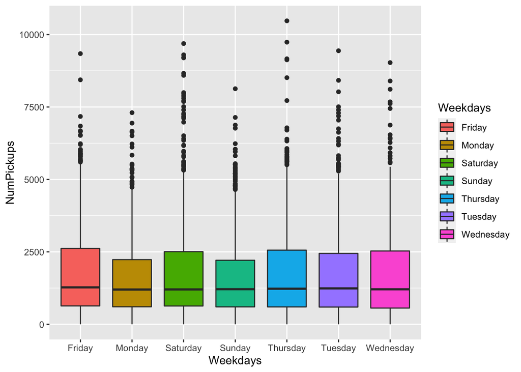

```r
uber_data$Weekdays <- as.Date(uber_data$Date)
uber_data$Weekdays <- weekdays(uber_data$Weekdays)
uber_data %>%
  group_by(Weekdays, `No. of Pickups`) %>%
  summarize(NumPickups=sum(`No. of Pickups`)) %>%
  ggplot(uber_data, mapping=aes(x = Weekdays, y = NumPickups, fill=Weekdays)) + geom_boxplot() + scale_y_continuous()
```

This is a box and whisker plot of the number of pick ups based on weekdays. The reason we chose to use this plot is because it gives us useful values of measure of central tendency that tells us about our data. For example, we can see the the median number of pick ups is relatively the same across any week day but the upper quartile changes more drastically than the median. We can also see the max values for each day which differs throughout each day. This change in maximums can possibly explain the changes in the upper quartile. For example, the upper quartile is significantly lower on Monday than it is on Friday and when we look at the maximum values for Friday, we can see that it is significantly higher than that of Monday. By using this plot and the previous plot from 2.3, we can see that Thursdays are the most consistent for number of ubers.

### 3.1 Number of Pick Ups Versus Time by Month

```r
uber_data$date <- factor(as.Date(uber_data$Num_time))
uber_data$dtime <- as.POSIXct(sprintf('%s %s:%s', Sys.Date(),
                       format(uber_data$Num_time, '%H:%M'), '00'))
new_num <- uber_data %>%
  group_by(Time_Dbl, Month=floor_date(Num_time, "month")) %>%
  summarize(NumPickups=sum(`No. of Pickups`))

head(new_num)
```

```
## # A tibble: 6 x 3
## # Groups:   Time_Dbl [1]
##   Time_Dbl Month               NumPickups
##      <dbl> <dttm>                   <int>
## 1        0 2015-01-01 00:00:00      82911
## 2        0 2015-02-01 00:00:00     107110
## 3        0 2015-03-01 00:00:00     110695
## 4        0 2015-04-01 00:00:00     113751
## 5        0 2015-05-01 00:00:00     143861
## 6        0 2015-06-01 00:00:00     148381
```

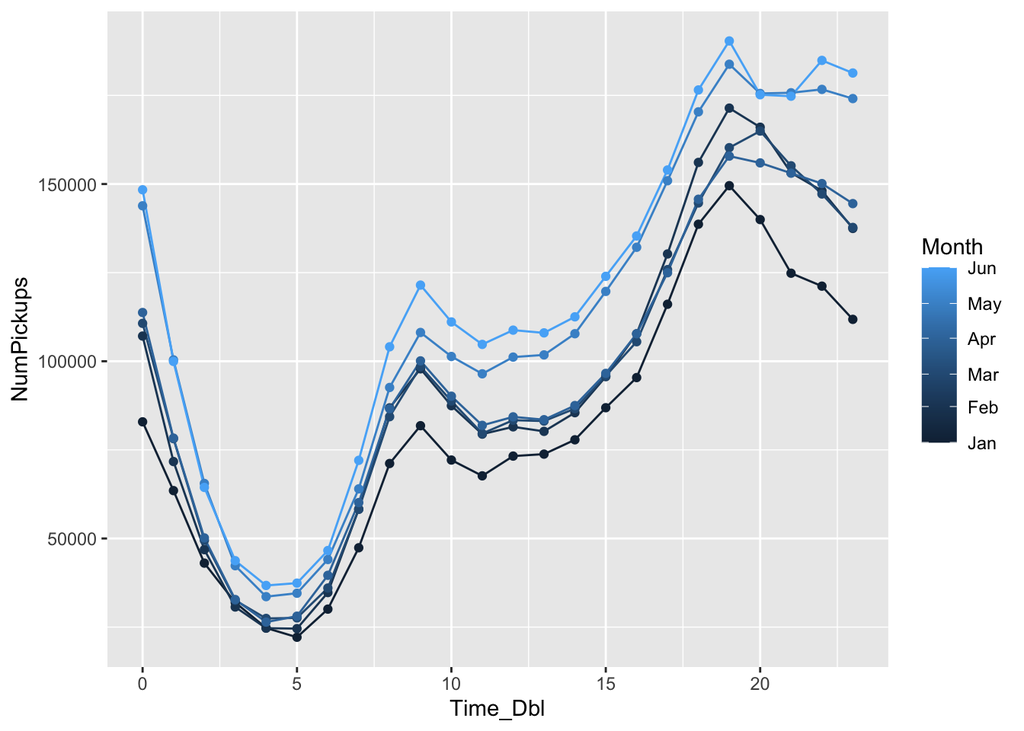

```r
ggplot(new_num, aes(x=Time_Dbl, y=NumPickups, group=Month, color=Month)) + geom_line() + geom_point()
```

The purpose of this plot was to see what time Uber pickups are most prevalent. We first made a new data fram from the existing larger data frame with all of the Uber data. In this new data frame (new_num), we first grouped by Time and Month. In our dataframe, time is represetnted as a number from 0-23 where 0 represents midnight and 23 represents 11:00PM. The data provided to us only had data for the hour which allowed us to use values from 0-23 to represent times.

We then summarized the data based on the sum of number of pick ups by month and time. The months represented in this dataframe is January through June. We then plotted the data using a line graph to show change over time.

### 3.2 Pickup per Hour Distributions by Borough

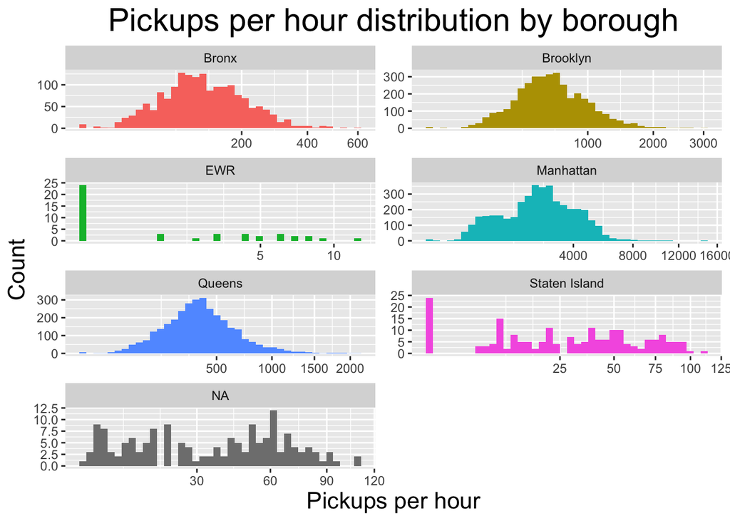

```r
uber_data %>%
  group_by(Time_Dbl, `No. of Pickups`, Borough) %>%
  summarize(NumPickups=sum(`No. of Pickups`)) %>%
  ggplot(subset(uber_data, !is.na(Borough)), mapping=aes(NumPickups)) +
  geom_histogram(mapping=aes(fill = Borough), bins = 40) +
  scale_x_sqrt() +
  facet_wrap(~ Borough, ncol = 2, scales = 'free') +
  labs(title = 'Pickups per hour distribution by borough',
  x = 'Pickups per hour', y = 'Count') +
  theme(plot.title = element_text(size = 22, hjust = 0.5),
  legend.position = 'none', axis.title = element_text(size = 16))
```

### 3.3 Regression Model Number of Pickups vs Month by Weekdays

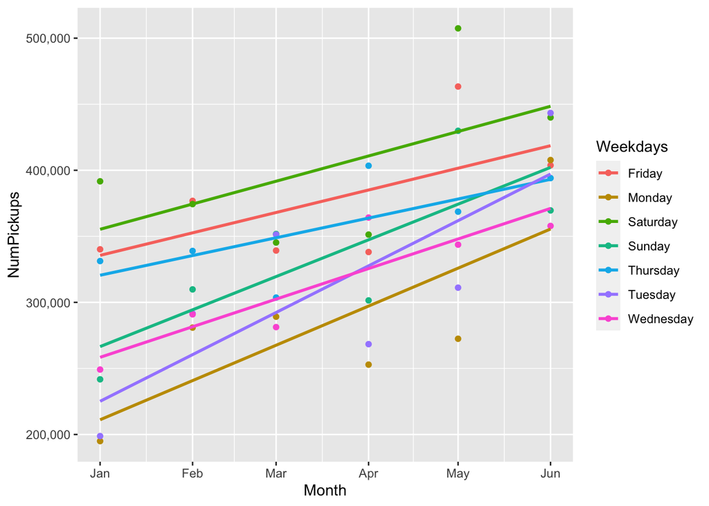

```r
uber_data$Weekdays <- as.Date(uber_data$Date)
uber_data$Weekdays <- weekdays(uber_data$Weekdays)

uber_data %>%
  group_by(Month=floor_date(FullDate, "month"), Weekdays) %>%
  summarize(NumPickups=sum(`No. of Pickups`)) %>%
  ggplot(uber_data, mapping=aes(x = Month, y = NumPickups, fill = Weekdays, color = Weekdays)) + geom_point() + scale_y_continuous(labels = scales::comma) + scale_fill_manual(values = cbp2) + geom_smooth(method = lm, aes(fill=Weekdays), se=FALSE, fullrange=TRUE)
```

To make this plot, we first created a pipe with uber_data. We used the group_by function first and grouped by Month and weekday. This splits our data up based on the month and weekday of the data. We then used a summarize function in order to figure out the amount of pick ups per day per month which we used to plot. Next, we used the ggplot function to create the actual plot. The first parameter indicates our dataset which is uber_data. The next parameter is the aesthetics parameter which has many other parameters within. The most important 2 are the x and y parameters which indicate what values to use for the x and y coordinate. The next parameter that we used was fill which fills the color of the lines based on the weekday.

After this, we wanted physical points on the plot so we added the ’+ geom_point()" parameter. The y axis was in scientific notation which is hard to read so the next parameter is used to place commas in the numerical values. The next parameter just indicates what color range to use with the graphs to make it more visually pleasing. The last parameter is the most important part where we implement a linear regression method which is based on the number of pick ups as well as the week day. On the plot, the linear line is fitted based on the value. This regression shows that the number of pick ups steadily increases for each week day as the month increases.

### 3.4 Number of Pickups vs Time Regression

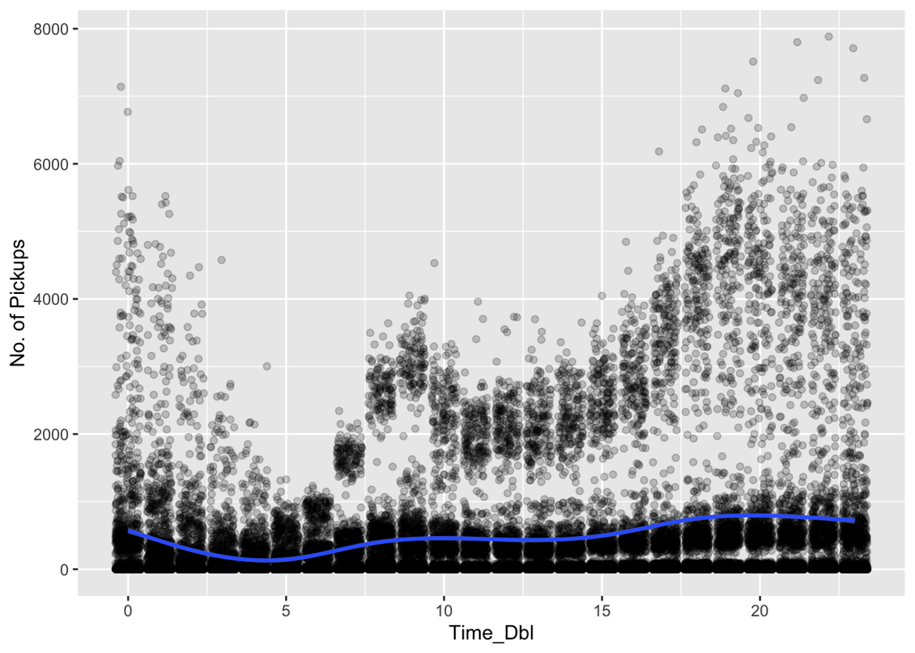

```r
library(tidyr)

ggplot(uber_data, aes(Time_Dbl, `No. of Pickups`)) + geom_jitter(alpha = 0.2) +
  geom_smooth()
```

### Conclusion

Based on our various hypotheses throughout the course of this tutorial, we concluded that time of day is the most prominent quantifiable variable that affects the number of pickups for Uber drivers. For people that are considering joining the force of Uber drivers, or current Uber drivers looking to maximize their time and effort, this tutorial contains a plethora of information that you may use to plan your occupational life out with Uber. We have put together a brief summary that may help you understand this experiment and its results and how you can use this information at your disposal.

If your primary concern in terms of Uber activity is location, then Manhattan is the borough that consistently has the highest number of pickups across the board.

If you are looking to work Uber part time or during other times of the day, then late at night (midnight to 2 AM) and anywhere from 5 PM to 10 PM shows the highest activity across the boroughs.

If you are trying to see what days of the week are the most promising, then Friday and Saturday have the most activity for the weekends and, for weekdays, Thursday has the most activity.

If you are trying to see if holidays have a major impact on the Uber activity in NYC, we deduced that there’s no positive correlation between holidays from work and Uber activity (at least for the first 6 months of the year).

### References/Other Resources

https://www.bloomberg.com/news/articles/2020-03-17/uber-drivers-say-earnings-fall-and-many-have-no-other-income https://movement.uber.com/?lang=en-US https://rstudio.com/products/rstudio/ https://www.rdocumentation.org/ https://www.kaggle.com/yannisp/uber-pickups-enriched https://data.world/

### TL;DR

Don’t work on holidays. Stay in Manhattan. Be active anytime from 12:00AM-2:00AM or 5:00PM-11:00PM. June is lit. :)